# Generalized Soft Impute for Matrix Completion

Max Turgeon

University of Manitoba

## Motivation

- Missing data is common in every data science domain
- Often, methods assume the data is complete or (silently) perform a complete-case analysis.
  - Data imputation
- Can we improve performance by leveraging structure in the data?

## Common methods

- Complete-case analysis
- Mean imputation
  - Also median/mode imputation
- Often leads to imprecise and/or biased results

## Example

Removing missing data can be misleading

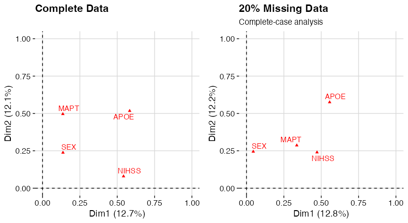

## Outline

1. Matrix factorization and matrix completion
2. Generalized SVD
3. **Generalized Soft Impute**
4. Simulations

# Matrix factorization and matrix completion

## Non-Negative Matrix Factorization

- Let $A$ be a $n\times p$ non-negative matrix
  - For NNMF, all entries are non-negative.
- Want: $G, H$ non-negative such that $A \approx GH$.
  - Distance? *Frobenius norm* of difference
  - Can take $G,H$ of rank $r < \min(n,p)$.
- Lee and Seung (2001) gave iterative algorithm with entrywise updates.
  - We can skip over missing data!

## Iterative PCA

- PCA gives us decomposition of $A = Z V^T$, with $V$ containing the eigenvectors of $\mathrm{Cov}(A)$.
- Missing data?
  - Randomly impute.
  - Compute PCA and use decomposition to update imputation.
  - Repeat until convergence.
- Control overfitting via 1) Choosing a small number $r$ of eigenvectors/PCs and 2) $L_2$ regularization

## Soft Impute

- Define a projection operator:

$$[P_\Omega(X)]_{ij} = \begin{cases} X_{ij} & (i,j)\in \Omega\\ 0 & (i,j) \notin \Omega\end{cases}.$$

$$f(X) = \frac{1}{2} \| P_\Omega(A) - P_\Omega(X) \|_F^2 + \lambda \|X\|_\ast.$$

- We have:
  - $\| \cdot \|_F$: Frobenius norm
  - $\| \cdot \|_\ast$: Nuclear norm (i.e. sum of singular values)
  - $\lambda$: Tuning parameter
- Convex optimization! But nuclear norm is not differentiable…
- Mazumder et al. (2010) proposed an efficient algorithm based on *proximal gradient descent*.

## Summary

- Matrix factorization = structure
- Learn structure = make good guesses
- Avoid overfitting with small rank and regularization

# Generalized Singular Value Decomposition

## Generalized SVD

- **Generalized SVD** differs from SVD by introducing positive-definite matrices representing *row* and *column* constraints.
- $A$ is $n\times p$ matrix, $M$ represents row constraints, $W$ represents column constraints.
- We want matrices U, D, V, with D diagonal, such that

$$A = UDV^T, \qquad U^TMU = V^TWV = I.$$

- Define $\tilde{A} = M^{1/2}A W^{1/2}$.
- Compute SVD: $\tilde{A} = P D Q^T$.
- Rescale: $U=M^{-1/2}P$ and $V = W^{-1/2}Q$.

We can get a rank $r$ approximation by taking the first $r$ columns of $U,V$, and the first $r$ diagonal entries of $D$:

$$A \approx U_{[r]} D_{[r]} V_{[r]}^T.$$

## Multiple Correspondence Analysis

- Think PCA for categorical data.
- Use one-hot encoding to get 0/1 matrix (observed counts).
- Compute matrix of expected counts under independence (row frequencies times column frequencies)
- Run generalized SVD on the difference matrix.
  - $M$ is a diagonal matrix of inverse row frequencies
  - $W$ is a diagonal matrix of inverse column frequencies

# Generalized Soft Impute

## Our method

- The rank $r$ matrix $U_{[r]} D_{[r]} V_{[r]}^T$ (for fixed $r> 0$) minimizes the following:

$$f(X) = \frac{1}{2}\mathrm{trace}\left(M(A-X) W (A-X)^T\right),\quad \mathrm{rank}(X) \leq r.$$

- **Key idea**: Compute $f(X)$ for non-missing values of $A$, and *penalize the nuclear norm* (i.e. sum of singular values).

$$X_\mathrm{compl} = \mathrm{\arg\!\min}\, \left\{f(X) + \lambda\|X\|_*\right\}$$

## Algorithm

- Iterate until convergence:
  - Fill missing entries of $A$ using previous iteration.
  - Compute generalized SVD for $A = UDV^T$.
  - Soft-threshold singular values: $X = US_\lambda(D)V^T$.

Recall: $S_\lambda(\sigma) = \max(\sigma - \lambda, 0)$.

## Aside: Proximal gradient descent

- Convex and differentiable objective function $g(X)$:
  - **Gradient descent**: $X^{t+1} = X^t - \gamma \nabla g(X^t)$
- What can we do if non-differentiable? *It depends*
- Assume we can write $g = f + h$ in two parts:
  - $f$ is convex and differentiable
  - $h$ is only convex
- Define the proximal map:

$$\mathrm{prox}_h(X) = \mathrm{argmin}_{\Theta} \left\{\frac{1}{2}\|X - \Theta \|_2^2 + h(\Theta)\right\}.$$

- Sometimes, the proximal map is easy to compute:
  - $h$ = indicator function of convex set $\to$ $\mathrm{prox}_h$ = projection operator
  - $h$ = L<sub>1</sub> norm $\to$ $\mathrm{prox}_h$ = soft-thresholding (e.g. Lasso)
  - $h$ = nuclear norm $\to$ $\mathrm{prox}_h$ = *matrix* soft-thresholding
- **Proximal gradient descent**
  - $X^{t+1} = \mathrm{prox}_{\gamma h}\left(X^t - \gamma \nabla g(X^t)\right)$

## Summary

- Proximal gradient descent is useful when objective is non-differentiable, with simple non-differentiable part.
- Convergence guarantees when $g$ is Lipshitz
- Can be accelerated just like GD

# Simulations

## Simulation scenario

- We use data from ONDRI.<sup>1</sup>
  - Sex, NIH stroke scale score, APOE genotype, MAPT diplotype
- We randomly remove a fixed proportion of data ($\pi_{miss}$).
- We compare imputed data to original data.
- We compare four methods:
  - *Generalized Soft Impute*, Soft Impute, Iterative PCA, and Regularized Iterative PCA.
[^1]: Ontario Neurodegenerative Disease Research Initiative

## Results

| $\pi_{miss}$ | *GSI* | SI | iPCA | riPCA |
| --- | --- | --- | --- | --- |
| 0.05 | **0.0974** | 0.1053 | 0.1032 | 0.1032 |
| 0.10 | **0.2040** | 0.2284 | 0.2152 | 0.2152 |
| 0.15 | **0.3037** | 0.3688 | 0.3115 | 0.3115 |
| 0.20 | 0.4318 | 0.4925 | **0.4085** | **0.4085** |
| 0.25 | 0.5796 | 0.6251 | **0.5145** | **0.5145** |

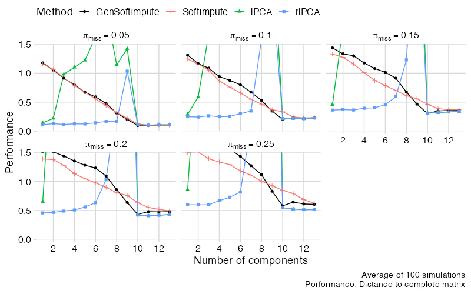

## Discussion

- Our method outperforms Soft Impute.
- For small $\pi_{miss}$, GSI is better than iterative PCA.
- For larger $\pi_{miss}$, riPCA is better than GSI.
  - **BUT** requires the right rank!

Overall, leveraging structure in data does improve performance.

## Discussion (cont’d)

- We assumed data is MCAR.
  - Reasonable when data missing because of technical failure
- Need more simulations to understand behaviour with MAR data.

## Summary

- We presented a matrix completion algorithm specifically designed for methods built on **generalized SVD** (e.g. weighted PCA, MCA).
- We achieved robustness by penalizing the nuclear norm of the approximating matrix.
- Proximal gradient descent theory guarantees convergence.
- Especially useful for compositional data (e.g. ecology, microbiome data).

## Next steps

- Hyperparameter selection ($\lambda$ and $r$)
- Application to microbiome data
  - Missing data a consequence of low read depth
- Improve computational efficiency by leveraging sparsity
- Release `GenSoftImpute` package

Development version can be found here: github.com/turgeonmaxime/GenSoftImpute

## Questions?

### Slides can be found at maxturgeon.ca/talks

[figure not shown]

Generalized Soft Impute